# Projet_Multidim_ACP

En résumé, ces données fournissent des informations précieuses sur la structure des données, les relations entre les variables et les individus, ainsi que sur la clusterisation potentielle des données.

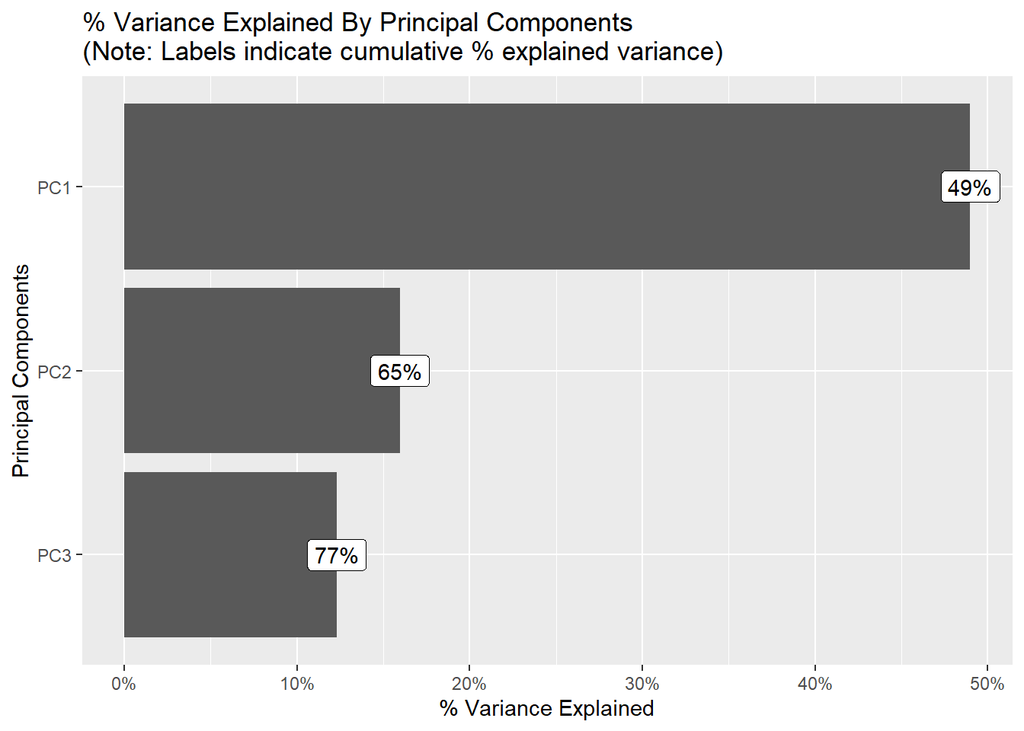

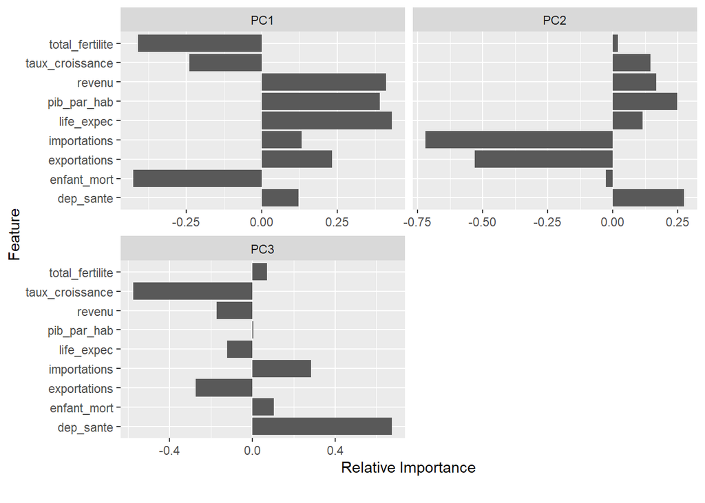

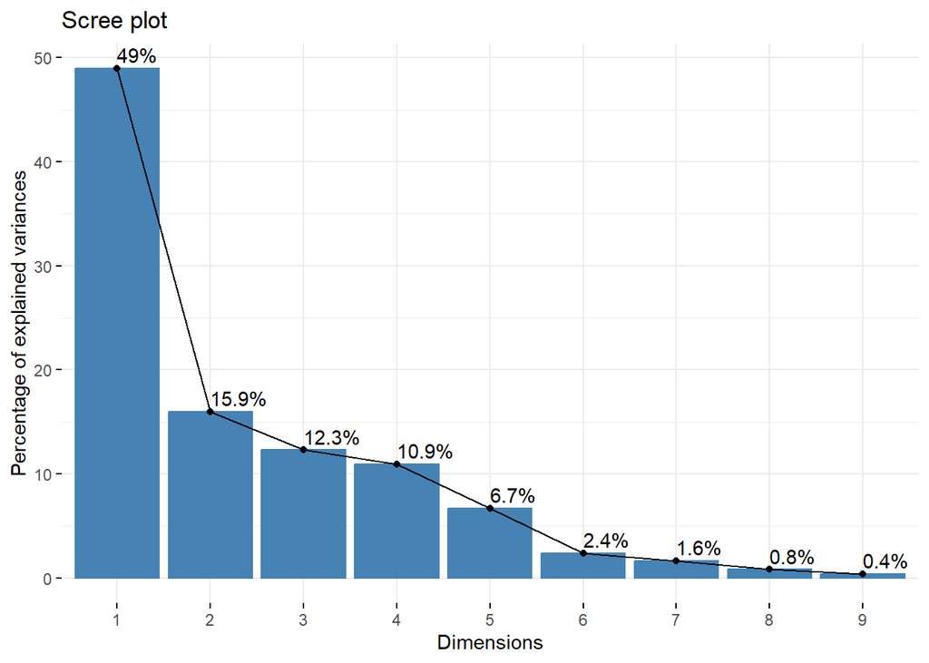

## Visualisation de la qualité de la représentation des variables

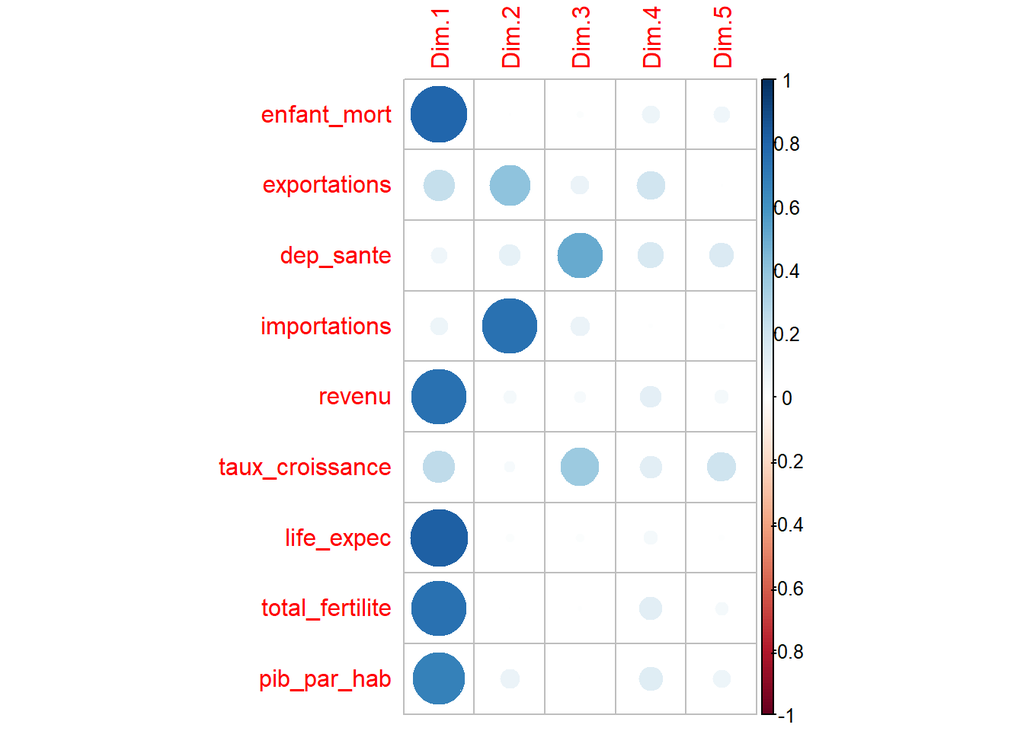

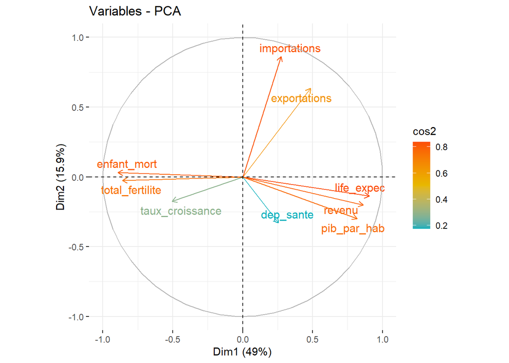

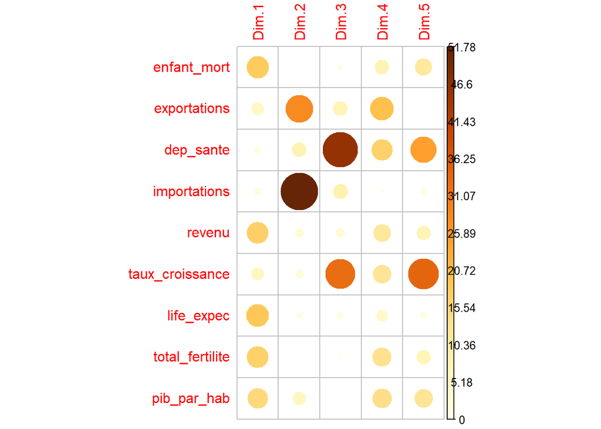

## Visualisation de la qualité de la représentation des observations

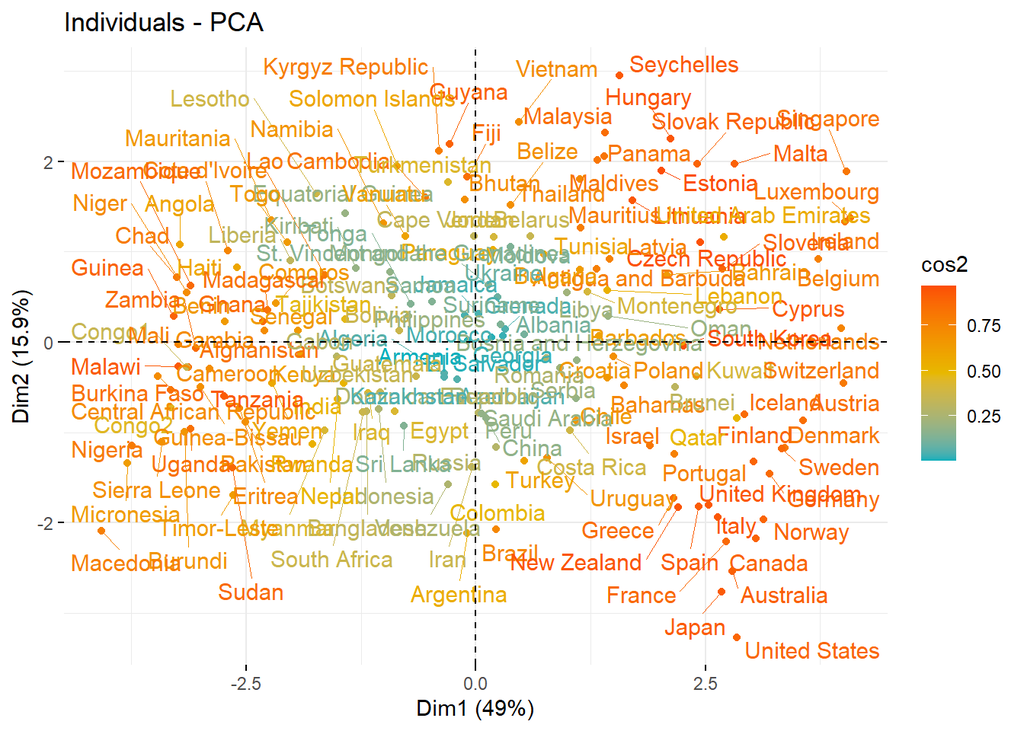

## PARTIE III : LA CLASSIFICATION DES DONNEES

## Détermination de l’échantillon

Présentons un échantillon de 50 enregistrements à partir du jeu de données afin que le graphe ne soit pas Surchargé.

## Faisabilité de l’analyse de clustering

De plus il faut vérifier la faisabilité de l’analyse de clustering en calculant la statistique Hopkins.

```
## $hopkins_stat
## [1] 0.8824324
##
## $plot
## NULL
```

Le résultat du test de Hopkins est de 0.8824324, ce qui suggère une tendance élevée des données à former des clusters. Cela indique que les données sont propices à la clusterisation.

## Détermination du nombre optimal de clusters

FactoMiner nous suggere d’utiliser la partition ayant la plus grande perte relative d’inertie. Nous allons calculer cet indicateur avec best.cutree. L’extension JLutils propose une fonction best.cutree qui permet de calculer cette indicateur à partir de n’importe quel dendrogramme calculé avec hclust ou agnes. Par défaut, best.cutree regarde quelle serait la meilleure partition entre 3 et 20 classes.

## Nombre optimal de cluster

En l’occurence il s’agirait d’une partition en 3 classes.

```
## [1] 3
```

## Visualisation de la classification

[output not shown]

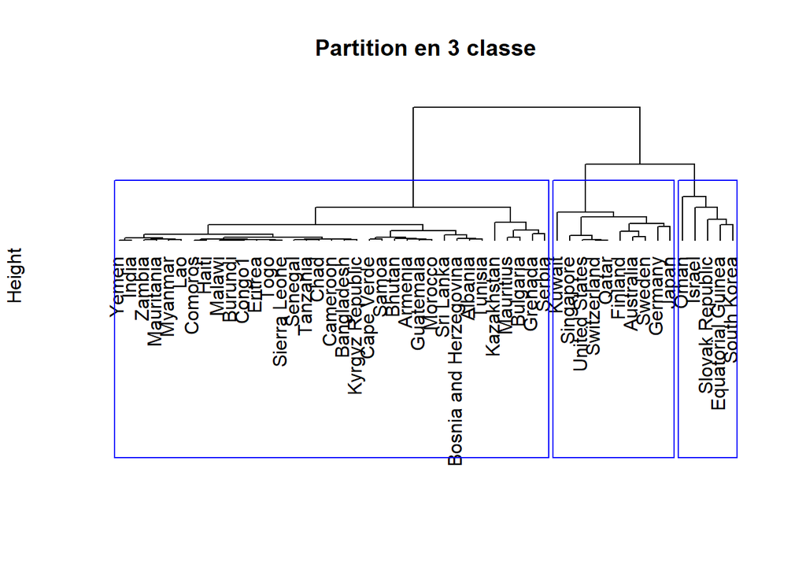

## Affectation des individus à chaque classe

|  | x |
| --- | --- |
| Cape Verde | 1 |
| Bangladesh | 1 |
| Myanmar | 1 |
| Germany | 2 |
| Finland | 2 |
| Bosnia and Herzegovina | 1 |
| Burundi | 1 |
| Oman | 3 |
| Togo | 1 |
| Sierra Leone | 1 |
| Yemen | 1 |
| Mauritius | 1 |
| Cameroon | 1 |
| Switzerland | 2 |
| Qatar | 2 |
| Albania | 1 |
| Tanzania | 1 |
| Malawi | 1 |
| Tunisia | 1 |
| Congo1 | 1 |
| Zambia | 1 |
| Kazakhstan | 1 |
| Grenada | 1 |
| Lao | 1 |
| Bhutan | 1 |
| Kuwait | 2 |
| Mauritania | 1 |
| Israel | 3 |
| India | 1 |
| Guatemala | 1 |
| Senegal | 1 |
| Samoa | 1 |
| Singapore | 2 |
| Equatorial Guinea | 3 |
| South Korea | 3 |
| Slovak Republic | 3 |
| Chad | 1 |
| Australia | 2 |
| Sri Lanka | 1 |
| Japan | 2 |
| Comoros | 1 |
| Kyrgyz Republic | 1 |
| Sweden | 2 |
| Haiti | 1 |
| Armenia | 1 |
| Serbia | 1 |
| Eritrea | 1 |
| Morocco | 1 |
| United States | 2 |
| Bulgaria | 1 |

## Implémentation de l’algorithme K-means avec k = best

Nous pouvons à présent implémenter l’algorithme k-means à l’ensemble de nos données en considérant Best comme nombre de clusters optimal.

```
## K-means clustering with 3 clusters of sizes 96, 31, 40
##
## Cluster means:
##   enfant_mort exportations dep_sante importations    revenu taux_croissance
## 1   57.418750     32.35260  6.400469     43.73542  5099.004        8.940896
## 2    5.765161     49.43903  8.261677     41.92000 42042.258        4.139697
## 3   15.353000     48.39025  6.973250     47.15550 20487.500        6.503700
##   life_expec total_fertilite pib_par_hab
## 1   65.61188        3.771365    2345.575
## 2   79.90645        1.911290   40477.097
## 3   74.85000        1.954250   12884.500
##
## Clustering vector:
##                    Afghanistan                        Albania
##                              1                              1
##                        Algeria                         Angola
##                              1                              1
##            Antigua and Barbuda                      Argentina
##                              3                              3
##                        Armenia                      Australia
##                              1                              2
##                        Austria                     Azerbaijan
##                              2                              3
##                        Bahamas                        Bahrain
##                              3                              2
##                     Bangladesh                       Barbados
##                              1                              3
##                        Belarus                        Belgium
##                              3                              2
##                         Belize                          Benin
##                              1                              1
##                         Bhutan                        Bolivia
##                              1                              1
##         Bosnia and Herzegovina                       Botswana
##                              1                              1
##                         Brazil                         Brunei
##                              3                              2
##                       Bulgaria                   Burkina Faso
##                              3                              1
##                        Burundi                       Cambodia
```

[output cut: 135 more lines]

```
##                        Vanuatu                      Venezuela
##                              1                              3
##                        Vietnam                          Yemen
##                              1                              1
##                         Zambia
##                              1
##
## Within cluster sum of squares by cluster:
## [1] 1677396973 3526160050 2409405779
##  (between_SS / total_SS =  89.8 %)
##
## Available components:
##
## [1] "cluster"      "centers"      "totss"        "withinss"     "tot.withinss"
## [6] "betweenss"    "size"         "iter"         "ifault"
```

Évidemment, trois clusters sont formés et cela est conforme à notre paramètre k qui a été transmis à l’algorithme. Nous voyons que le premier groupe contient 96 observations, le deuxième groupe contient 31 observations et le troisième groupe contient 40 observations. Chacune des observations de notre ensemble des données est affectée à l’un de ces trois groupes (1, 2 ou 3).

## Visualisation des résultats avec Kmeans

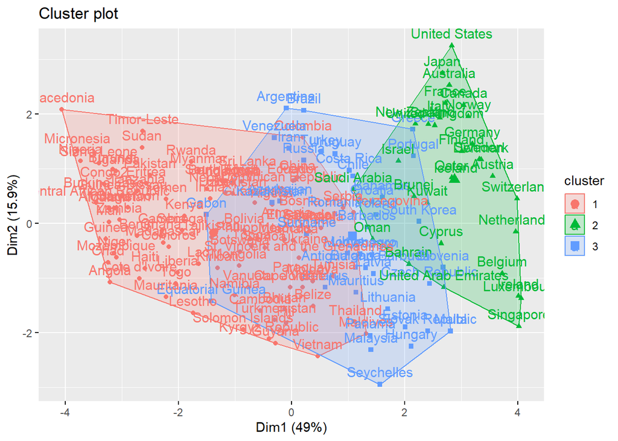

## Visualisation du clustering par le dendogramme

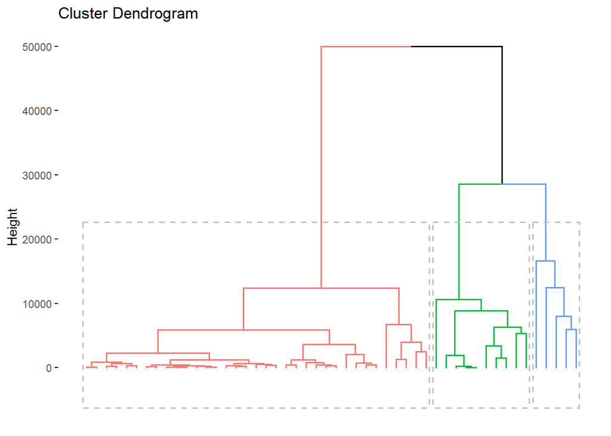

## Qualité de la segmentation

En Apprentissage supervisé, on dispose de données étiquettées ce qui permet de comparer les prédictions du modèle aux réelles observations. En apprentissage non-supervisé, comme c’est le cas ici, cette comparaison ne peut se faire car les données ne sont pas étiquettées. Comment mesurer alors la qualité de notre partitionnement ?

L’objectif du clustering est d’obtenir des clusters de bonne qualité. Le clustering est de haute qualité si la distance dans les observations (intra-cluster) d’un cluster donné est minimale et la distance séparant les clusters eux-mêmes (inter-cluster) est maximale. Malheureusement, il n’y aucune valeur seuil (ou valeur de référence) pour dire la distance intra-cluster est minimale ou si la distance inter-cluster est maximale.

Pour mesurer la qualité du clustering, on peut calculer le coefficient de Silhouette pour chacun des trois groupes. L’indice Silhouette est calculé en utilisant la distance intra-cluster moyenne, a, et la distance moyenne du cluster le plus proche, b, pour chacune des observations participant à l’exercice de clustering. Pour une observation, l’indice Silhouette est donné par la formule : (b - a)/max(a, b).

```
## Silhouette of 167 units in 3 clusters from silhouette.default(x = kmeans_out$cluster, dist = dist(Help_I, "euclidean")) :
##  Cluster sizes and average silhouette widths:
##        96        31        40
## 0.7144976 0.5912875 0.4481125
## Individual silhouette widths:
##    Min. 1st Qu.  Median    Mean 3rd Qu.    Max.
## 0.02487 0.53888 0.72813 0.62782 0.80236 0.82581
```

La silhouette de 167 unités réparties en 3 clusters à partir de la fonction silhouette.default(x = kmeans_out$cluster, dist = dist(Help_I, “euclidean”)) indique les tailles des clusters et les largeurs moyennes des silhouettes :

- Le premier cluster contient 96 unités avec une largeur moyenne de silhouette de 0,7144976.
- Le deuxième cluster contient 31 unités avec une largeur moyenne de silhouette de 0,5912875.
- Le troisième cluster contient 40 unités avec une largeur moyenne de silhouette de 0,4481125.

Les largeurs de silhouette individuelles varient de manière significative : - La plus faible largeur de silhouette est de 0,02487. - Le premier quartile est de 0,53888. - La médiane est de 0,72813. - La moyenne est de 0,62782. - Le troisième quartile est de 0,80236. - La plus grande largeur de silhouette est de 0,82581.

Ces informations permettent d’évaluer la cohésion et la séparation des clusters. Une valeur de silhouette proche de 1 indique une bonne séparation entre les clusters, tandis qu’une valeur proche de 0 indique un chevauchement entre les clusters.

## Centre de gravité de chaque cluster

```
##   enfant_mort exportations dep_sante importations    revenu taux_croissance
## 1   57.418750     32.35260  6.400469     43.73542  5099.004        8.940896
## 2    5.765161     49.43903  8.261677     41.92000 42042.258        4.139697
## 3   15.353000     48.39025  6.973250     47.15550 20487.500        6.503700
##   life_expec total_fertilite pib_par_hab
## 1   65.61188        3.771365    2345.575
## 2   79.90645        1.911290   40477.097
## 3   74.85000        1.954250   12884.500
```

## Indice moyen observé chez les patients pour chaque groupe

```
## [1] 7662.811
## [1] 82710.7
## [1] 33573.18
```

## Catégorisation par classification ascendante hierarchique

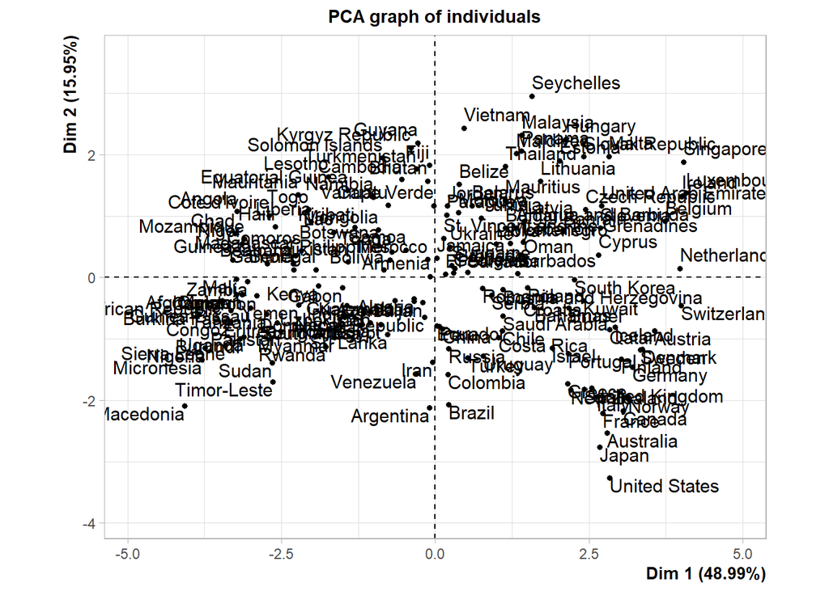

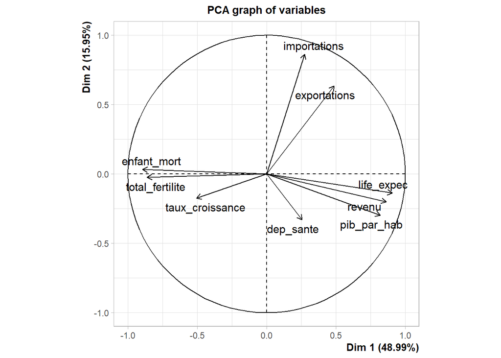

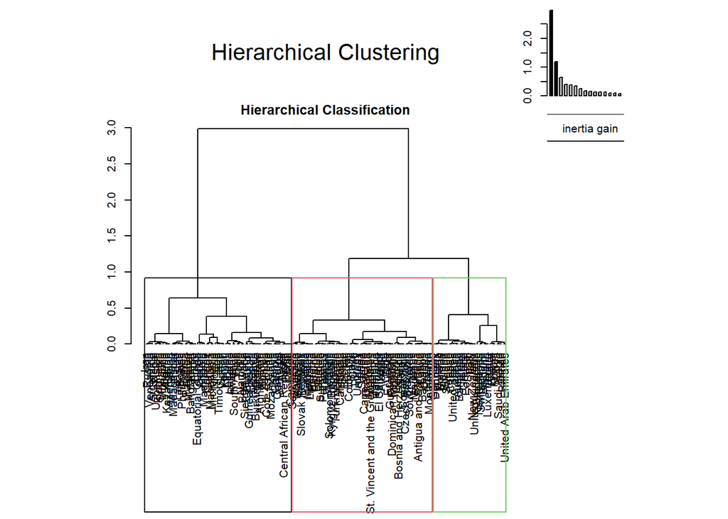

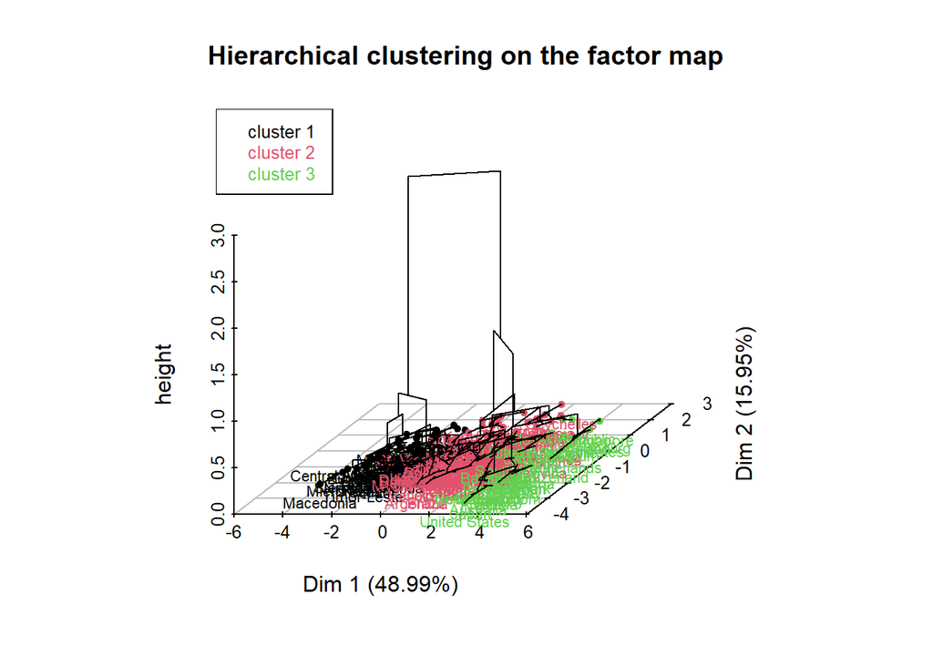

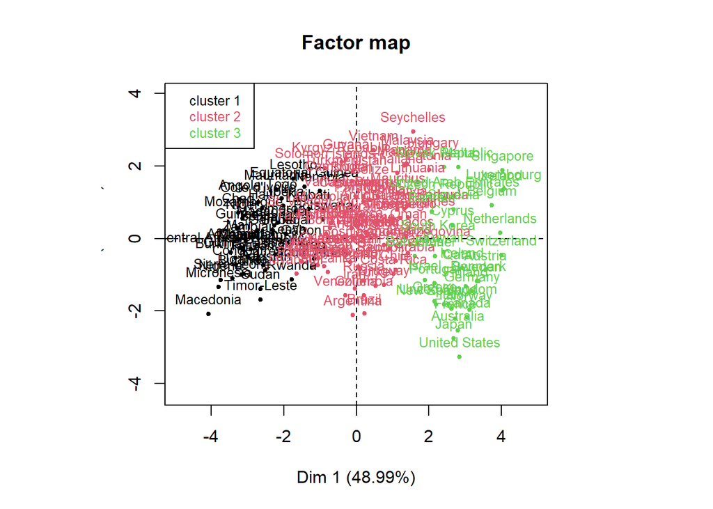

```
## [1] "data.clust" "desc.var"   "desc.axes"  "desc.ind"   "call"
```

|  | enfant_mort | exportations | dep_sante | importations | revenu | taux_croissance | life_expec | total_fertilite | pib_par_hab | clust |
| --- | --- | --- | --- | --- | --- | --- | --- | --- | --- | --- |
| Afghanistan | 90.2 | 11.86 | 7.58 | 44.90 | 1610 | 9.44 | 56.2 | 5.82 | 553 | 1 |
| Albania | 16.6 | 28.00 | 6.55 | 48.60 | 9930 | 4.49 | 76.3 | 1.65 | 4090 | 2 |
| Algeria | 27.3 | 38.40 | 4.17 | 31.40 | 12900 | 16.10 | 76.5 | 2.89 | 4460 | 2 |
| Angola | 115.4 | 62.30 | 2.85 | 42.90 | 5900 | 22.40 | 60.1 | 6.16 | 3530 | 1 |
| Antigua and Barbuda | 10.3 | 45.50 | 6.03 | 58.90 | 19100 | 1.44 | 76.8 | 2.13 | 12200 | 2 |
| Argentina | 14.5 | 18.90 | 8.10 | 16.36 | 18700 | 20.90 | 75.8 | 2.37 | 10300 | 2 |

## CARACTERISATION DES CLUSTERS PAR LES VARIABLES

```
##
## Link between the cluster variable and the quantitative variables
## ================================================================
##                      Eta2      P-value
## pib_par_hab     0.8416152 2.379638e-66
## enfant_mort     0.8235035 1.707462e-62
## life_expec      0.7969290 1.687023e-57
## total_fertilite 0.7709906 3.220838e-53
## revenu          0.7511760 2.905162e-50
## taux_croissance 0.1748644 1.429152e-07
## dep_sante       0.1470039 2.175984e-06
## exportations    0.1292176 1.181924e-05
##
## Description of each cluster by quantitative variables
## =====================================================
## $`1`
##                     v.test Mean in category Overall mean sd in category
## enfant_mort      11.468078        88.359184    37.754731     22.2005071
## total_fertilite  11.167942         5.033694     2.990844      0.9729316
## taux_croissance   4.237241        11.012143     7.465896      7.9790748
## importations     -2.261705        39.153878    44.217605     16.5790304
## exportations     -3.999366        29.726531    39.365689     17.3103089
## pib_par_hab      -5.550731      1822.310204 11948.174850   2879.4230142
## revenu           -6.663677      3754.579592 15642.601198   5498.4217687
## life_expec      -10.749312        59.466122    70.478084      4.6881704
##                   Overall sd      p.value
## enfant_mort        36.636095 1.908508e-30
## total_fertilite     1.518708 5.852115e-29
## taux_croissance     6.948594 2.262836e-05
## importations       18.588543 2.371561e-02
## exportations       20.010552 6.351251e-05
## pib_par_hab     15145.827443 2.844773e-08
## revenu          14811.762768 2.670606e-11
## life_expec          8.505407 5.970509e-27
##
## $`2`
##                    v.test Mean in category Overall mean sd in category
## life_expec       3.529649        72.879012    70.478084      3.9195211
## revenu          -2.824607     12296.666667 15642.601198   8134.9568811
## dep_sante       -3.820241         6.089160     6.883156      1.9564435
```

[output cut: 15 more lines]

```
## life_expec       7.537809        79.805405    70.478084   1.888650e+00
## dep_sante        4.657323         8.644027     6.883156   2.660329e+00
## exportations     3.568197        49.753514    39.365689   2.124743e+01
## taux_croissance -4.581525         2.834373     7.465896   3.766201e+00
## total_fertilite -5.535255         1.767838     2.990844   3.473073e-01
## enfant_mort     -6.080769         5.344324    37.754731   2.473523e+00
##                   Overall sd      p.value
## pib_par_hab     15145.827443 1.165322e-31
## revenu          14811.762768 9.620539e-27
## life_expec          8.505407 4.779350e-14
## dep_sante           2.598810 3.203470e-06
## exportations       20.010552 3.594468e-04
## taux_croissance     6.948594 4.615964e-06
## total_fertilite     1.518708 3.107752e-08
## enfant_mort        36.636095 1.196072e-09
```

### Lien entre la variable de cluster et les variables quantitatives

- **Eta2** : Il s’agit du carré du coefficient de corrélation entre chaque variable quantitative et la variable de cluster. Plus la valeur d’Eta2 est proche de 1, plus la variable est fortement liée au cluster.
- **P-value** : Il s’agit de la significativité statistique de la relation entre chaque variable quantitative et la variable de cluster. Une valeur de P-value faible (inférieure au seuil de signification généralement fixé à 0.05) indique une relation significative.

### Description de chaque cluster par variables quantitatives

Chaque cluster est décrit en termes de moyenne et de déviation standard pour chaque variable quantitative, ainsi que des tests statistiques associés (v-test) pour déterminer si les moyennes dans chaque cluster diffèrent significativement de la moyenne globale.

#### Cluster 2 :

- Ce cluster se caractérise par des valeurs intermédiaires pour la plupart des variables, mais surtout pour l’espérance de vie, le revenu, et la dépense de santé.
- Les différences observées dans les variables entre ce cluster et la moyenne globale sont également statistiquement significatives.

#### Cluster 3 :

- Ce cluster présente des valeurs élevées pour des variables telles que le revenu, l’espérance de vie, le PIB par habitant, etc.
- Les valeurs-p des tests statistiques indiquent des différences significatives dans ces variables entre ce cluster et la moyenne globale.

En résumé, l’analyse montre que les trois clusters se distinguent par leurs caractéristiques socio-économiques, avec des différences significatives dans plusieurs variables clés.

## CARACTERISATION DES CLUSTERS PAR LES DIMENSIONS (axe)

```
##
## Link between the cluster variable and the quantitative variables
## ================================================================
##             Eta2      P-value
## Dim.1 0.85172538 1.065319e-68
## Dim.4 0.40472634 3.363306e-19
## Dim.5 0.19785898 1.407860e-08
## Dim.2 0.08943539 4.607687e-04
## Dim.3 0.05620328 8.710317e-03
##
## Description of each cluster by quantitative variables
## =====================================================
## $`1`
##           v.test Mean in category  Overall mean sd in category Overall sd
## Dim.4   4.845353        0.5788746 -2.145240e-16      1.0131782  0.9919052
## Dim.3   2.283473        0.2892994 -2.446168e-16      1.1507254  1.0518717
## Dim.5  -2.978308       -0.2780086 -7.739204e-16      0.9113270  0.7749963
## Dim.1 -10.119543       -2.5592345 -1.718270e-15      0.7799347  2.0997146
##            p.value
## Dim.4 1.263870e-06
## Dim.3 2.240253e-02
## Dim.5 2.898444e-03
## Dim.1 4.525248e-24
##
## $`2`
##          v.test Mean in category  Overall mean sd in category Overall sd
## Dim.5  5.683290        0.3522509 -7.739204e-16      0.6172850  0.7749963
## Dim.2  3.266904        0.3130171  3.947275e-18      1.1504803  1.1980611
## Dim.3 -3.011056       -0.2532994 -2.446168e-16      0.9109187  1.0518717
## Dim.4 -8.188987       -0.6496105 -2.145240e-16      0.6001998  0.9919052
##            p.value
## Dim.5 1.321283e-08
## Dim.2 1.087306e-03
## Dim.3 2.603411e-03
## Dim.4 2.634336e-16
##
## $`3`
##          v.test Mean in category  Overall mean sd in category Overall sd
## Dim.1  9.341889        2.8537227 -1.718270e-15      0.6402982  2.0997146
## Dim.4  4.542422        0.6555026 -2.145240e-16      0.7038195  0.9919052
## Dim.2 -3.439248       -0.5994586  3.947275e-18      1.4124789  1.1980611
## Dim.5 -3.574017       -0.4029703 -7.739204e-16      0.4903900  0.7749963
##            p.value
## Dim.1 9.463012e-21
## Dim.4 5.561161e-06
## Dim.2 5.833333e-04
## Dim.5 3.515458e-04
```